# HW3-drafting-viz

### Written Responses

#### 1: Which option do you plan to pursue?

I still plan to pursue option 1, the infographic.

#### 2: Restate your questions. Has this changed at all since HW #1? If yes, how so?

My main questions as I described them in homework 1 was if metal content in mammal tissue correlates with proximity to mining areas. If so, what can this tell us about morphological differences in humans, if anything? As I continue to think about this project, my question does generally stay the same, but it also has expanded. I see the flow of my infographic answering these series of questions: What counties have the highest amounts of various metal contents in mammal tissue? What counties have the most proximity to mining sites? Do these things correlate?

#### 3: Explain which variables from your data set(s) you will use to answer your question(s), and how.

My data set has 40 variables, a lot of which will not be used in my analysis. The most important variables for me are the latitude, longitude, and county for spatial analysis, total_length to scale the metal content by the size of the animal, and the metal of choice. I’ve used mg so far for my analysis, but I am planning to use fe which might give me more helpful results as it relates to iron ore mining. I’ve combined this original dataset to another dataset that has all of the mining sites in Minnesota and the county where they are along with the type of mining. I am joining those two by county to plot them all together with the lat and long from the original dataset.

#### b. What ggplot extension tools / packages do you need to use to build your visualizations? Are there any that we haven’t covered in class that you’ll be learning how to use for your visualizations?

One important package for my spatial visualization is the tigris package, which allows me to underlay a shapefile of the state of Minnesota.

#### c. What feedback do you need from the instructional team and / or your peers to ensure that your intended message is clear?

### Code Set up

```r
# Load libraries
library(dplyr)
library(janitor)
library(ggplot2)
library(here)
library(tmap)
library(sf)
library(hrbrthemes)
library(tigris)
```

```r
# Read in and clean data
df <- read.csv('data/mammal_hvy_metals_by_pop_withGUIDs.csv') %>%
  clean_names() %>%
  filter(!is.na(latitude) & !is.na(longitude))
# add in more data cleaning post mortem, once I understand what variables I am interested in

mine_locations <- read.csv('data/mine_locations.csv') %>%
  clean_names()
```

### Visualizations

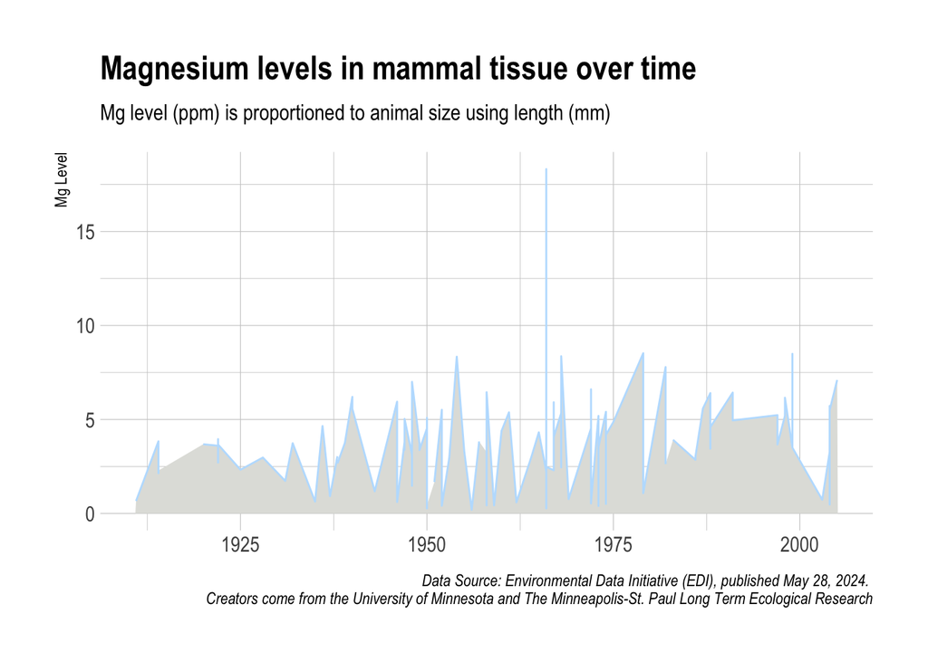

```r
# First data viz -> collections over time
df %>%
  mutate(mg_prop = mg/total_length) %>%
  ggplot(aes(x = year_collected, y = mg_prop)) +
  geom_area(fill = "#e0e1dd") +
  geom_line(color = "#bde0fe") +
  theme_minimal() +
  labs(
    title = "Magnesium levels in mammal tissue over time",
    subtitle = "Mg level (ppm) is proportioned to animal size using length (mm)",
    x = "Year",
    y = "Mg Level",
    caption = "Data Source: Environmental Data Initiative (EDI), published May 28, 2024. \nCreators come from the University of Minnesota and The Minneapolis-St. Paul Long Term Ecological Research") +
  theme_ipsum() +
  theme(axis.title.x = element_blank())
```

```r
# the average content of Mg in the body of most animals is about 0.4 Mg / kg of body weight
```

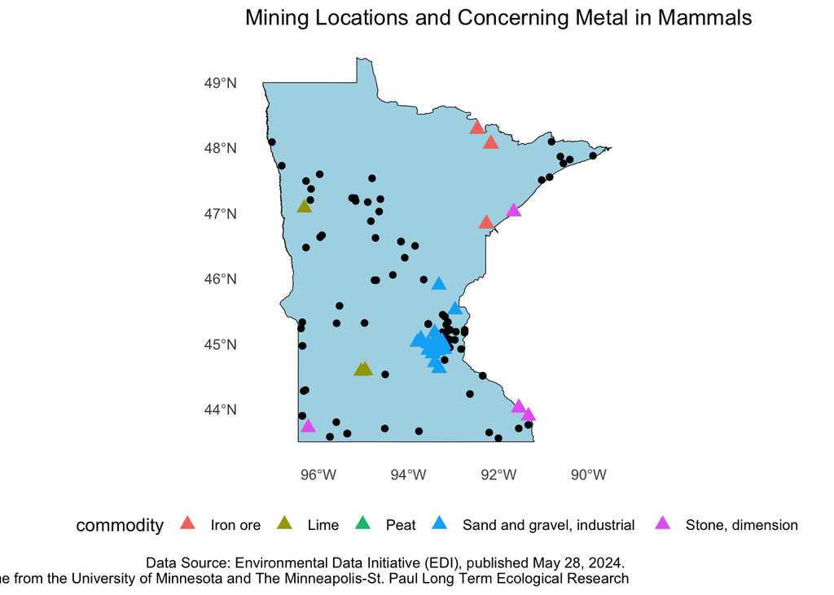

```r
# Second data viz -> use sf object to plot lat and long --> no longer doing this

# merge
mines_and_metals <- merge(x=df, y=mine_locations, by = "county", all.y=TRUE) %>%
  filter(!is.na(fe))

mining_locations <- mines_and_metals

mn_shapefile <- states(cb=TRUE) %>%
  filter(STUSPS == "MN")
ggplot() +
  geom_sf(data = mn_shapefile, fill = "lightblue", color = "black") +
  geom_point(data = df, aes(x = longitude, y = latitude)) +
  geom_point(data = mining_locations, aes(x = longitude, y = latitude, color = commodity), shape = 17, size = 3) +  # Overlay red triangles for mining sites
  labs(
    title = "Mining Locations and Concerning Metal in Mammals",
      caption = "Data Source: Environmental Data Initiative (EDI), published May 28, 2024. \nCreators come from the University of Minnesota and The Minneapolis-St. Paul Long Term Ecological Research"
    ) +
  guides(fill = guide_legend(title = "Mining type: ")) +
  theme_minimal() +
  theme(
    legend.position = "bottom",
    panel.grid = element_blank(),
    axis.title.x = element_blank(),
    axis.title.y = element_blank()
    )
```

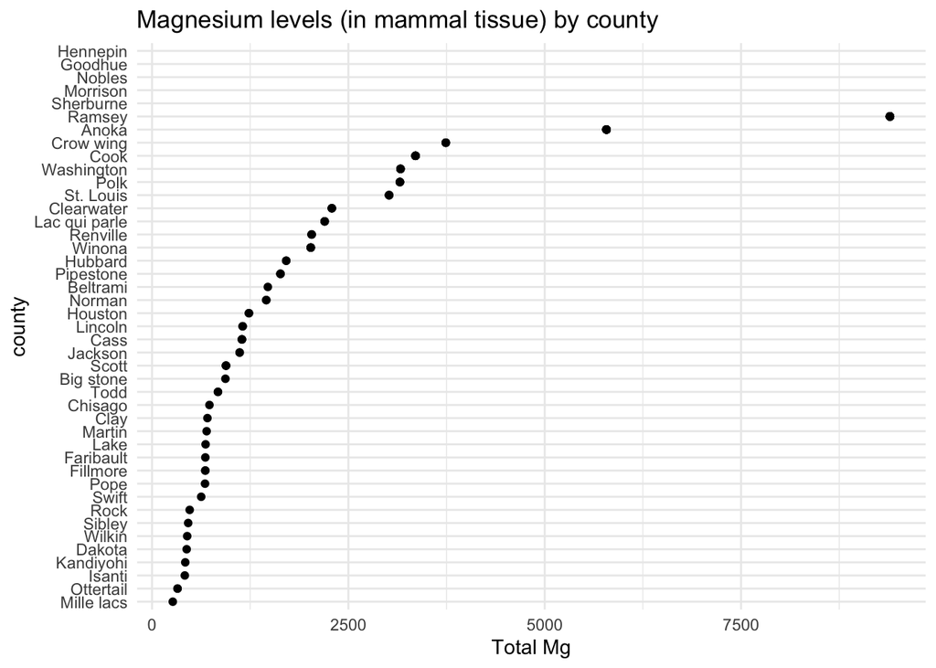

```r
# Third data viz -> sum magnesium levels by county
mg_df <- df %>%
  group_by(county) %>%
  mutate(total_mg = sum(mg)) %>%
  arrange(total_mg) %>%
  ungroup() %>%
  mutate(county = factor(county, levels = unique(county)))

ggplot(mg_df, aes(x = county, y = total_mg)) +
  geom_point() +
  coord_flip() +
  theme_minimal() +
  labs(
    title = "Magnesium levels (in mammal tissue) by county",
    y = "Total Mg"
  )
```

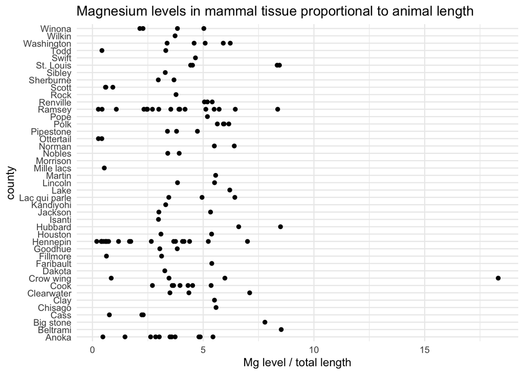

```r
# Third data viz -> sum magnesium levels by county
mg_df <- df %>%
  group_by(county) %>%
  mutate(total_mg = sum(mg)) %>%
  mutate(mg_prop = mg/total_length) %>%
  ungroup()

ggplot(mg_df, aes(x = county, y = mg_prop)) +
  geom_point() +
  coord_flip() +
  theme_minimal() +
  labs(
    title = "Magnesium levels in mammal tissue proportional to animal length",
    y = "Mg level / total length"
  )
```